# powerAnalysis

```r
# code sample
library(dplyr)
library(sandwich)
library(stargazer)
library(lmtest)
library(data.table)
```

```r
library(ggplot2)
library(knitr)

# custom
library(tidyr)
library(grid)
library(gridExtra)
set.seed(123)
```

# Research Question:

Does the gender or race of a potential customer affect response rates when requesting catering orders from U.S. states that historically supported slavery?

# Data Structure Plan of Record:

- Factor 1 Geographic Block: union, confederacy
  - Factor 2 Race Treatment: white / black names
    - Factor 3 Gender Treatment: male / female names
      - Outcome Variable 1: response (binary)
      - Outcome Variable 2: budget acceptance (binary / NA)
- Total combinations: 2^3 = 2x2x2 = 8 experimental cells

## Draft Response Rate Map of Scenario 1:

Rosen, J. (2010). *Legislative responsiveness to constituent ethnicity and grammar quality: A field experiment.*

| Geography | Race | Gender | Experiment Mapping | Gender Adjustment | Final Rate |
| --- | --- | --- | --- | --- | --- |
| Union | White | Male | 52 | 0 | 52 |
| Union | White | Female | 52 | TBD | TBD |
| Union | Black | Male | 37 | 0 | 37 |
| Union | Black | Female | 37 | TBD | TBD |
| Confederate | White | Male | 29 | 0 | 29 |
| Confederate | White | Female | 29 | TBD | TBD |
| Confederate | Black | Male | 34 | 0 | 34 |
| Confederate | Black | Female | 34 | TBD | TBD |

Drawn directly from the cell averages observed in the Jose versus Colin multi-factor experiment, which analyzed response rates in correspondence audits based on perceived ethnicity and grammar quality. Specifically, the 52% rate represents the response rate observed in the most favorable condition of that study (Colin with good grammar), which is used here to anchor the White Male response rate in the expected high-response Union region. The other source rates, 37% and 34%, correspond to less favorable experimental conditions in that study (e.g., Colin with bad grammar or Jose with bad grammar, respectively), reflecting lower response probability due to disadvantageous traits. These rates are applied across the geographies (Union/Confederate) and races (White/Black) to model expected discrimination, with lower rates generally assigned to the historically constrained Confederate region and to Black profiles. The table sets these initial rates as the male baseline (Gender Adjustment = 0), establishing the foundation for future analysis aimed at determining the necessary “Gender Adjustment” to calculate the final response rates for females in the study.

## Draft Response Rate Map Scenario 2

Bertrand, M., & Mullainathan, S. (2004). Are Emily and Greg more employable than Lakish and Jamal? A field experiment on labor market discrimination. American Economic Review.

| Geography | Race | Gender | Experiment Mapping | Gender Adjustment | Final Rate |
| --- | --- | --- | --- | --- | --- |
| Union | White | Male | 11.88 | 0.00 | 11.88 |
| Union | White | Female | 11.88 | +1.46 | 13.34 |
| Union | Black | Male | 7.83 | 0.00 | 7.83 |
| Union | Black | Female | 7.83 | +0.87 | 8.70 |
| Confederate | White | Male | 8.61 | 0.00 | 8.61 |
| Confederate | White | Female | 8.61 | +1.05 | 9.66 |
| Confederate | Black | Male | 5.81 | 0.00 | 5.81 |
| Confederate | Black | Female | 5.81 | +0.64 | 6.45 |

Callback rates derived from the Bertrand and Mullainathan (B&M) field experiment, “Are Emily and Greg More Employable than Lakisha and Jamal?”. The rates used here are the percentage callback rates from the B&M study. To proxy for the geographical split (Union/Confederate), this simulation uses the observed callback rates from B&M’s Boston data (higher rates, proxy for Union) and Chicago data (lower rates, proxy for Confederate), aligning with the expectation that rates might be lower in historically slave-owning regions. The initial ‘Jose Mapping’ rates represent the anchored male rates observed by race in these proxy cities, with the ‘Gender Adjustment’ calculated by applying the difference in gender ratios (female rate relative to male rate) observed across the overall B&M sample to these anchors. The final rates illustrate the core finding of B&M that African American names received approximately 50 percent fewer callbacks for interviews compared to White names, with the gender adjustment reflecting the fact that females in that experiment often received slightly higher rates than males within the same racial group.

## Draft Response Rate Map of Scenario 3

Block, R., Crabtree, C., Holbein, J. B., & Monson, J. Q. (2021). Are Americans less likely to reply to emails from Black people relative to White people. Proceedings of the National Academy of Sciences.

| Geography | Race | Gender | Experiment Mapping | Gender Adjustment | Final Rate |
| --- | --- | --- | --- | --- | --- |
| Union | White | Male | 4.20 | 0.00 | 4.20 |
| Union | White | Female | 4.20 | TBD | TBD |
| Union | Black | Male | 3.90 | 0.00 | 3.90 |
| Union | Black | Female | 3.90 | TBD | TBD |
| Confederate | White | Male | 1.60 | 0.00 | 1.60 |
| Confederate | White | Female | 1.60 | TBD | TBD |
| Confederate | Black | Male | 1.40 | 0.00 | 1.40 |
| Confederate | Black | Female | 1.40 | TBD | TBD |

Observed response rates reported in Block et al. (2021), focus on the differential treatment of putatively White and Black senders. The initial ‘Jose Mapping’ rates for the Union proxy are anchored to the higher response rates observed among elected officials (4.2% for White senders and 3.9% for Black senders). The Confederate proxy uses the lower response rates observed across the general public sample (1.6% for White senders and 1.4% for Black senders), reflecting the expected lower rates in historically slave-owning regions. This structure directly models the finding that Black senders received fewer responses than White senders, a difference that Block et al. found to be statistically significant. Since the Block et al. study held gender status constant in the initial design summary and did not provide gender-specific rate breakdowns in the excerpts, the ‘Gender Adjustment’ remains TBD for the female categories.

## Assessing Feasibility

1. Responses have massively different scales
2. Gender is unspecified for Scenarios 1 and 3
3. We map Geography from 3 constructs: (Direct from grammar, Boston/Chicago proxy, and Officials/Public proxy)
4. Race effects have inconsistent magnitudes

# Final Scenarios, Imputation Strategy, & Assumptions:

## **Scenario 1: Colin Good Grammar.** Rosen, J. (2010). *Legislative responsiveness to constituent ethnicity and grammar quality: A field experiment.*

[output not shown]

Note that this particular scenario shows that Black Males will receive higher responses in Confederate states. *This contradicts our assumptions regarding the distribution of responses*, because we are using the effect sizes observed in the Jose vs. Colin experimental data literally (adjusted only for gender). Since this is merely a counterfactual state of the world, and a science fiction table, we are leaving it at is without manipulation or pre-selection. The plots will directly show measurable comparisons across block cohorts, irrespective of these theoretical response rates.

## **Scenario 2: Bertrand, M., & Mullainathan, S. (2004). Are Emily and Greg more employable than Lakisha and Jamal?**

[output not shown]

## **Scenario 3: Block, R., Crabtree, C., Holbein, J. B., & Monson, J. Q. (2021)**

[output not shown]

# Experiment Proposal Task Decomposition:

- Design: JH/DS
  - Geographic Blocking, done
  - Race treatment, done
  - Gender treatment, done
  - One restaurant receives one treatment, done
- Outcomes: JH/DS
  - Response rate (binary), done
  - Budget acceptance (binary / NA), done
- Sample: JH/DS
  - Restaurants / caterers as subjects, done
  - Regional stratification & balance, done
- Analysis: JH/DS
  - Regression with robust SE, done
  - Discrimination effects, done
  - Regional differences, done
  - Plots, done

```r
# Total sample size
n <- 400

geography <- c("Union", "Confederate")
race <- c("White", "Black")
gender <- c("Male", "Female")
```

```r
# Create a balanced design: 100 observations per combination
design <- expand.grid(
    geography = geography,
    race = race,
    gender = gender
)
design
```

```
##     geography  race gender
## 1       Union White   Male
## 2 Confederate White   Male
## 3       Union Black   Male
## 4 Confederate Black   Male
## 5       Union White Female
## 6 Confederate White Female
## 7       Union Black Female
## 8 Confederate Black Female
```

```r
design$n <- n / nrow(design) # 50 per cell at n=400
design
```

```
##     geography  race gender  n
## 1       Union White   Male 50
## 2 Confederate White   Male 50
## 3       Union Black   Male 50
## 4 Confederate Black   Male 50
## 5       Union White Female 50
## 6 Confederate White Female 50
## 7       Union Black Female 50
## 8 Confederate Black Female 50
```

```r
# Assign reply rates for Scenario 1 (Jose/Colin based):

multi_female1and3 <- c(1.46, 0.87, 1.05, 0.64)  # order: union-white, union-black, confed-white, confed-black
add_female2 <- c(1.46, 0.87, 1.05, 0.64)

# Scenario 1
design$reply_rate1 <- c(
  52,
  37,
  29,
  34,
  52 + 1.46,
  37 + 0.87,
  29 + 1.05,
  34 + 0.64
)

# Scenario 2
design$reply_rate2 <- c(
  0.1188 * 100,   # white-union-male
  0.0783 * 100,     # black-union-male
  0.0861 * 100,  # white-confederate-male
  0.0581 * 100,    # black-confederate-male
  0.1188 * 100 + add_female2[1],    # white-union-female
  0.0783 * 100 + add_female2[2],     # black-union-female
  0.0861 * 100 + add_female2[3],     # white-confederate-female
  0.0581 * 100 + add_female2[4]  # black-confederate-female
)

# Scenario 3
design$reply_rate3 <- c(
  4.20,
  3.90,
  1.60,
  1.40,
  4.20 + 1.46,
  3.90 + 0.87,
  1.60 + 1.05,
  1.40 + 0.64
)
```

```r
# Generate the data
generate_data <- function(race_level, geo_level, gender_level, n, reply_rate1, reply_rate2, reply_rate3) {
    response1 <- rbinom(n, size = 1, prob = reply_rate1/100)
    response2 <- rbinom(n, size = 1, prob = reply_rate2/100)
    response3 <- rbinom(n, size = 1, prob = reply_rate3/100)

    # assume 70% baseline, reduced by 15% for Black names
    budget_base_prob <- ifelse(race_level == "White", 0.70, 0.55)

    # budget acceptance conditioned on response=1 (aka receiving a response at all)
    budget_accept1 <- ifelse(response1 == 1, rbinom(n, 1, budget_base_prob), NA)
    budget_accept2 <- ifelse(response2 == 1, rbinom(n, 1, budget_base_prob), NA)
    budget_accept3 <- ifelse(response3 == 1, rbinom(n, 1, budget_base_prob), NA)

    data.frame(
        race = rep(race_level, n),
        geography = rep(geo_level, n),
        gender = rep(gender_level, n),
        received_reply1 = response1,
        received_reply2 = response2,
        received_reply3 = response3,
        budget_accepted1 = budget_accept1,
        budget_accepted2 = budget_accept2,
        budget_accepted3 = budget_accept3
    )
}
```

```r
experiment_data <- design %>%
    rowwise() %>%
    do(generate_data(
        .$race,
        .$geography,
        .$gender,
        .$n,
        .$reply_rate1,
        .$reply_rate2,
        .$reply_rate3
    )) %>%
    ungroup()

experiment_data
```

```
## # A tibble: 400 × 9
##    race  geography gender received_reply1 received_reply2 received_reply3
##    <fct> <fct>     <fct>            <int>           <int>           <int>
##  1 White Union     Male                 1               0               0
##  2 White Union     Male                 0               0               0
##  3 White Union     Male                 1               0               0
##  4 White Union     Male                 0               0               0
##  5 White Union     Male                 0               0               0
##  6 White Union     Male                 1               0               0
##  7 White Union     Male                 0               0               0
##  8 White Union     Male                 0               0               0
##  9 White Union     Male                 0               1               0
## 10 White Union     Male                 1               0               0
## # ℹ 390 more rows
## # ℹ 3 more variables: budget_accepted1 <int>, budget_accepted2 <int>,
## #   budget_accepted3 <int>
```

```r
print("Reply rates by cell:")
```

```
## [1] "Reply rates by cell:"
```

```r
experiment_data %>%
    group_by(race, geography, gender) %>%
    summarise(
        n = n(),
        scenario1_actual = mean(received_reply1),
        scenario2_actual = mean(received_reply2),
        scenario3_actual = mean(received_reply3),
        .groups = "drop"
    ) %>%
    print()
```

```
## # A tibble: 8 × 7
##   race  geography   gender     n scenario1_actual scenario2_actual
##   <fct> <fct>       <fct>  <int>            <dbl>            <dbl>
## 1 White Union       Male      50             0.5              0.08
## 2 White Union       Female    50             0.6              0.08
## 3 White Confederate Male      50             0.38             0.12
## 4 White Confederate Female    50             0.32             0.04
## 5 Black Union       Male      50             0.4              0.06
## 6 Black Union       Female    50             0.32             0.14
## 7 Black Confederate Male      50             0.38             0.06
## 8 Black Confederate Female    50             0.38             0.1
## # ℹ 1 more variable: scenario3_actual <dbl>
```

```r
balance_check <- experiment_data %>%
    group_by(geography, race, gender) %>%
    summarise(n = n(), .groups = "drop")

print("Regional Balance Check:")
```

```
## [1] "Regional Balance Check:"
```

```r
print(balance_check)
```

```
## # A tibble: 8 × 4
##   geography   race  gender     n
##   <fct>       <fct> <fct>  <int>
## 1 Union       White Male      50
## 2 Union       White Female    50
## 3 Union       Black Male      50
## 4 Union       Black Female    50
## 5 Confederate White Male      50
## 6 Confederate White Female    50
## 7 Confederate Black Male      50
## 8 Confederate Black Female    50
```

```r
# checkequal allocations across geos
assert_balanced <- all(balance_check$n == 50)
cat(sprintf("\nBalanced design confirmed: %s\n", assert_balanced))
```

```
##
## Balanced design confirmed: TRUE
```

```r
# summary statistics by reply rates
summary_stats <- design %>%
  select(-n) %>%
  mutate(
    expected_rate1 = reply_rate1,
    expected_rate2 = reply_rate2,
    expected_rate3 = reply_rate3
  )
```

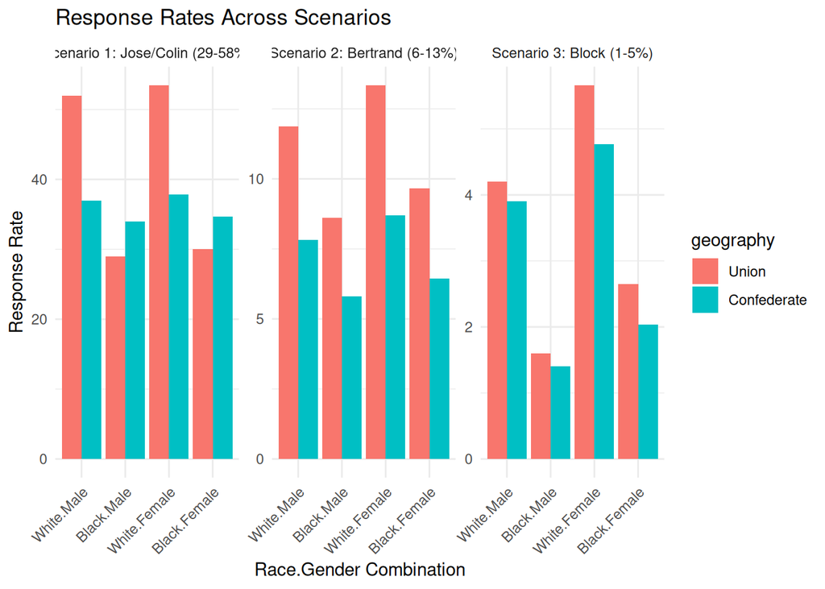

```r
plot_data <- design %>%
  select(race, geography, gender, reply_rate1, reply_rate2, reply_rate3) %>%
  pivot_longer(cols = starts_with("reply_rate"),
               names_to = "scenario",
               names_prefix = "reply_rate",
               values_to = "rate")

ggplot(plot_data, aes(x = interaction(race, gender), y = rate, fill = geography)) +
  geom_bar(stat = "identity", position = "dodge") +
  facet_wrap(~scenario, scales = "free_y",
             labeller = labeller(scenario = c("1" = "Scenario 1: Jose/Colin (29-58%)",
                                              "2" = "Scenario 2: Bertrand (6-13%)",
                                              "3" = "Scenario 3: Block (1-5%)"))) +
  theme_minimal() +
  theme(axis.text.x = element_text(angle = 45, hjust = 1)) +
  labs(title = "Response Rates Across Scenarios",
       x = "Race.Gender Combination",
       y = "Response Rate")
```

```r
# budget acceptance rates
experiment_data %>%
  group_by(race) %>%
  summarise(
    scenario1_budget_accept = mean(budget_accepted1, na.rm = TRUE),
    scenario2_budget_accept = mean(budget_accepted2, na.rm = TRUE),
    scenario3_budget_accept = mean(budget_accepted3, na.rm = TRUE),
    .groups = "drop"
  ) %>%
  print(row.names = FALSE)
```

```
## # A tibble: 2 × 4
##   race  scenario1_budget_accept scenario2_budget_accept scenario3_budget_accept
##   <fct>                   <dbl>                   <dbl>                   <dbl>
## 1 White                   0.744                   0.812                   0.75
## 2 Black                   0.568                   0.667                   0.667
```

[output not shown]

```r
# simplify conditioning with indicator variable option
experiment_data <- experiment_data %>%
  mutate(
    R = ifelse(race == "White", 0, 1), # race indicator
    G = ifelse(geography == "Union", 0, 1), # geography indicator
    S = ifelse(gender == "Male", 0, 1)# sex/gender indicator
  )
```

```r
head(experiment_data)
```

```
## # A tibble: 6 × 12
##   race  geography gender received_reply1 received_reply2 received_reply3
##   <fct> <fct>     <fct>            <int>           <int>           <int>
## 1 White Union     Male                 1               0               0
## 2 White Union     Male                 0               0               0
## 3 White Union     Male                 1               0               0
## 4 White Union     Male                 0               0               0
## 5 White Union     Male                 0               0               0
## 6 White Union     Male                 1               0               0
## # ℹ 6 more variables: budget_accepted1 <int>, budget_accepted2 <int>,
## #   budget_accepted3 <int>, R <dbl>, G <dbl>, S <dbl>
```

```r
table(experiment_data$geography, experiment_data$race, experiment_data$gender)
```

```
## , ,  = Male
##
##
##               White Black
##   Union          50    50
##   Confederate    50    50
##
## , ,  = Female
##
##
##               White Black
##   Union          50    50
##   Confederate    50    50
```

```r
# test regional differences in discrimination
test_regional_differences <- function(data, scenario_col) {
    # subset by geography
    union_data <- filter(data, geography == "Union")
    confed_data <- filter(data, geography == "Confederate")

    # calculate discrimination effect in each region
    union_model <- lm(as.formula(paste(scenario_col, "~ race")), data = union_data)
    union_race_effect <- coef(union_model)["raceBlack"]

    confed_model <- lm(as.formula(paste(scenario_col, "~ race")), data = confed_data)
    confed_race_effect <- coef(confed_model)["raceBlack"]

    # difference in discrimination between regions
    regional_diff <- confed_race_effect - union_race_effect

    return(list(
        union_effect = union_race_effect,
        confederate_effect = confed_race_effect,
        difference = regional_diff
    ))
}

# test regional differences for each scenario
regional1 <- test_regional_differences(experiment_data, "received_reply1")
regional2 <- test_regional_differences(experiment_data, "received_reply2")
regional3 <- test_regional_differences(experiment_data, "received_reply3")

print("Regional Discrimination Differences - Scenario 1:")
```

```
## [1] "Regional Discrimination Differences - Scenario 1:"
```

```r
print(regional1)
```

```
## $union_effect
## raceBlack
##     -0.19
##
## $confederate_effect
## raceBlack
##      0.03
##
## $difference
## raceBlack
##      0.22
```

```r
print("Regional Discrimination Differences - Scenario 2:")
```

```
## [1] "Regional Discrimination Differences - Scenario 2:"
```

```r
print(regional2)
```

```
## $union_effect
## raceBlack
##      0.02
##
## $confederate_effect
##    raceBlack
## 8.426965e-17
##
## $difference
## raceBlack
##     -0.02
```

```r
print("Regional Discrimination Differences - Scenario 3:")
```

```
## [1] "Regional Discrimination Differences - Scenario 3:"
```

```r
print(regional3)
```

```
## $union_effect
##    raceBlack
## -3.66048e-18
##
## $confederate_effect
## raceBlack
##     -0.02
##
## $difference
## raceBlack
##     -0.02
```

```r
test_discrimination_effects <- function(data, scenario_col) {
    formula <- as.formula(paste(scenario_col, "~ race * geography * gender"))
    model <- lm(formula, data = data)
    robust_se <- vcovHC(model, type = "HC0")
    coef_test <- coeftest(model, vcov = robust_se)

    # extract all discrimination-relevant effects
    effects <- list(
        race_main = coef_test["raceBlack", ],
        geography_main = coef_test["geographyConfederate", ],
        gender_main = coef_test["genderFemale", ],
        race_x_geography = coef_test["raceBlack:geographyConfederate", ],
        race_x_gender = coef_test["raceBlack:genderFemale", ],
        geography_x_gender = coef_test["geographyConfederate:genderFemale", ],
        three_way = coef_test["raceBlack:geographyConfederate:genderFemale", ]
    )

    return(effects)
}

# test all three scenarios
disc_effects_s1 <- test_discrimination_effects(experiment_data, "received_reply1")
disc_effects_s2 <- test_discrimination_effects(experiment_data, "received_reply2")
disc_effects_s3 <- test_discrimination_effects(experiment_data, "received_reply3")

# display results
print("Scenario 1 Discrimination Effects:")
```

```
## [1] "Scenario 1 Discrimination Effects:"
```

```r
print(disc_effects_s1$race_main)
```

```
##    Estimate  Std. Error     t value    Pr(>|t|)
## -0.10000000  0.09899495 -1.01015254  0.31304532
```

```r
print(disc_effects_s1$race_x_geography)
```

```
##   Estimate Std. Error    t value   Pr(>|t|)
##  0.1000000  0.1386506  0.7212372  0.4711935
```

```r
# function to run single simulation and test race effect
run_single_simulation <- function(n, scenario_num) {
  # calculate observations per cell

  n_per_cell <- n %/% 8
  remainder <- n %% 8
  cell_sizes <- c(rep(n_per_cell + 1, remainder), rep(n_per_cell, 8 - remainder))
  expanded_design <- design[rep(1:8, times = cell_sizes), ]


  if (scenario_num == 1) {
    response_probs <- expanded_design$reply_rate1
  } else if (scenario_num == 2) {
    response_probs <- expanded_design$reply_rate2
  } else if (scenario_num == 3) {
    response_probs <- expanded_design$reply_rate3
  }

  sim_data <- data.frame(
    race = expanded_design$race,
    geography = expanded_design$geography,
    gender = expanded_design$gender,
    response = rbinom(nrow(expanded_design), size = 1, prob = response_probs/100)
  )

  # fit linear model: response ~ race + geography + gender

  model <- lm(response ~ race + gender + geography + race:geography, data = sim_data)


  # compute robust se
  robust_se <- vcovHC(model, type = "HC0")

  # extract p-value for race coefficient
  coef_test <- coeftest(model, vcov = robust_se)
  p_value <- coef_test["raceBlack:geographyConfederate", "Pr(>|t|)"]

  return(p_value)
}
```

```r
# calculate power through repeated simulations
calculate_power <- function(n, scenario_num, n_sims = 100) {
  # run n_sims simulations and collect p-values
  p_values <- replicate(n_sims, run_single_simulation(n, scenario_num))
  # calculate proportion of simulations with p < 0.05
  power <- mean(p_values < 0.05)
  cat(sprintf("Scenario %d, n=%d: Power = %.3f\n", scenario_num, n, power))
  return(power)
}
```

```r
generate_power_curves <- function() {
  sample_sizes <- c(100, 200, 400, 600, 800, 1000, 1200, 1250, 1400, 1500, 1600, 1750, 1800, 1900, 2000, 5000, 10000)
  power_results <- data.frame(
    scenario = integer(),
    sample_size = integer(),
    power = numeric())
  for (scenario in 1:3) {
    cat(sprintf("\n Running Scenario %d \n", scenario))
    for (n in sample_sizes) {
      # calculate power for this combination
      power <- calculate_power(n, scenario, n_sims = 1000)
      power_results <- rbind(power_results,
                           data.frame(scenario = scenario,
                                    sample_size = n,
                                    power = power))}}
  power_results$scenario_label <- factor(power_results$scenario,
                                        levels = 1:3,
                                        labels = c("Scenario 1: Jose/Colin (29-58%)",
                                                  "Scenario 2: Bertrand (6-13%)",
                                                  "Scenario 3: Block (1-5%)"))
  return(power_results)}
```

```r
plot_power_curves <- function(power_results) {
  p <- ggplot(power_results, aes(x = sample_size, y = power,
                                  color = scenario_label,
                                  linetype = scenario_label)) +
    geom_line(linewidth = 1.2) +
    geom_point(size = 3) +
    labs(title = "Power Analysis",
         subtitle = "Power to detect race * geo interaction using regression with robust SE",
         x = "Sample Size (total n)",
         y = "Statistical Power",
         color = "Scenario",
         linetype = "Scenario") +
    scale_y_continuous(limits = c(0, 1),
                      breaks = seq(0, 1, by = 0.2),
                      labels = scales::percent) +
    scale_x_continuous(breaks = c(100, 200, 400, 600, 800, 1000, 1200, 1250, 1400, 1500, 1600, 1750, 1800, 1900, 2000, 5000, 10000)) +
    theme_minimal() +
    theme(legend.position = "bottom",
          legend.direction = "vertical",
          plot.title = element_text(size = 14, face = "bold"),
          plot.subtitle = element_text(size = 11, face = "italic"))
  p <- p + annotate("text", x = 1800, y = 0.82,
                    label = "80% power",
                    size = 3,
                    color = "red")
  return(p)
}
```

```r
power_results <- generate_power_curves()
```

```
##
##  Running Scenario 1
## Scenario 1, n=100: Power = 0.196
## Scenario 1, n=200: Power = 0.327
## Scenario 1, n=400: Power = 0.578
## Scenario 1, n=600: Power = 0.729
## Scenario 1, n=800: Power = 0.837
## Scenario 1, n=1000: Power = 0.922
## Scenario 1, n=1200: Power = 0.965
## Scenario 1, n=1250: Power = 0.964
## Scenario 1, n=1400: Power = 0.979
## Scenario 1, n=1500: Power = 0.979
## Scenario 1, n=1600: Power = 0.986
## Scenario 1, n=1750: Power = 0.994
## Scenario 1, n=1800: Power = 0.992
## Scenario 1, n=1900: Power = 0.994
## Scenario 1, n=2000: Power = 0.998
## Scenario 1, n=5000: Power = 1.000
## Scenario 1, n=10000: Power = 1.000
##
##  Running Scenario 2
## Scenario 2, n=100: Power = 0.059
## Scenario 2, n=200: Power = 0.048
## Scenario 2, n=400: Power = 0.062
## Scenario 2, n=600: Power = 0.051
## Scenario 2, n=800: Power = 0.063
## Scenario 2, n=1000: Power = 0.063
## Scenario 2, n=1200: Power = 0.085
## Scenario 2, n=1250: Power = 0.068
## Scenario 2, n=1400: Power = 0.081
## Scenario 2, n=1500: Power = 0.070
## Scenario 2, n=1600: Power = 0.081
## Scenario 2, n=1750: Power = 0.080
## Scenario 2, n=1800: Power = 0.071
## Scenario 2, n=1900: Power = 0.110
## Scenario 2, n=2000: Power = 0.087
## Scenario 2, n=5000: Power = 0.114
## Scenario 2, n=10000: Power = 0.206
##
##  Running Scenario 3
## Scenario 3, n=100: Power = NA
## Scenario 3, n=200: Power = 0.052
## Scenario 3, n=400: Power = 0.038
## Scenario 3, n=600: Power = 0.040
## Scenario 3, n=800: Power = 0.045
## Scenario 3, n=1000: Power = 0.046
## Scenario 3, n=1200: Power = 0.049
## Scenario 3, n=1250: Power = 0.058
## Scenario 3, n=1400: Power = 0.044
## Scenario 3, n=1500: Power = 0.035
## Scenario 3, n=1600: Power = 0.047
## Scenario 3, n=1750: Power = 0.047
## Scenario 3, n=1800: Power = 0.055
## Scenario 3, n=1900: Power = 0.057
## Scenario 3, n=2000: Power = 0.051
## Scenario 3, n=5000: Power = 0.049
## Scenario 3, n=10000: Power = 0.068
```

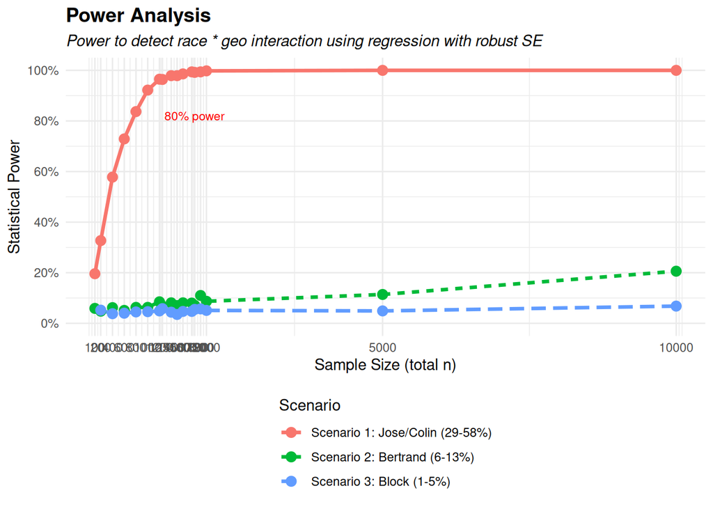

```r
power_plot <- plot_power_curves(power_results)
print(power_plot)
```

```r
write.csv(power_results, "power_analysis_results.csv", row.names = FALSE)
```

```r
create_discrimination_plot <- function() {
  # Calculate effect sizes for each scenario
  effect_data <- data.frame(
    scenario = rep(c("Scenario 1", "Scenario 2", "Scenario 3"), each = 4),
    geography = rep(rep(c("Union", "Confederate"), each = 2), 3),
    gender = rep(c("Male", "Female", "Male", "Female"), 3),
    white_rate = c(
      52, 53.46, 29, 30.05,  # Scenario 1
      11.88, 13.34, 8.61, 9.66,  # Scenario 2
      4.20, 5.66, 1.60, 2.65  # Scenario 3
    ),
    black_rate = c(
      37, 37.87, 34, 34.64,  # Scenario 1
      7.83, 8.70, 5.81, 6.45,  # Scenario 2
      3.90, 4.77, 1.40, 2.04  # Scenario 3
    ))

  effect_data$discrimination <- effect_data$white_rate - effect_data$black_rate
  ggplot(effect_data, aes(x = interaction(geography, gender), y = discrimination, fill = geography)) +
    geom_bar(stat = "identity", position = "dodge") +
    geom_hline(yintercept = 0, linetype = "dashed", alpha = 0.5) +
    facet_wrap(~scenario, scales = "free_y", nrow = 1) +
    labs(title = "Discrimination effect sizes across experimental cells",
         subtitle = "Observable tau percentage point difference : White - Black response rates",
         x = "Geography × Gender",
         y = "Discrimination Effect (pp)") +
    scale_fill_manual(values = c("Union" = "#2166ac", "Confederate" = "#b2182b")) +
    theme_minimal() +
    theme(axis.text.x = element_text(angle = 45, hjust = 1),
          legend.position = "top",
          plot.title = element_text(size = 16, face = "bold"))}
```

```r
generate_summary_report <- function(power_results) {
  # Sample sizes for 80% power
  for(s in unique(power_results$scenario_label)) {
    scenario_data <- filter(power_results, scenario_label == s)
    power_80_n <- scenario_data$sample_size[which(scenario_data$power >= 0.80)[1]]
    if(is.na(power_80_n)) power_80_n <- ">2000"

    cat(sprintf("%s:\n", s))
    cat(sprintf("  - Sample size for 80%% power: n = %s\n", power_80_n))
    cat(sprintf("  - Power at n=400: %.1f%%\n",
                100 * scenario_data$power[scenario_data$sample_size == 400]))
    cat(sprintf("  - Power at n=1000: %.1f%%\n\n",
                100 * scenario_data$power[scenario_data$sample_size == 1000]))
  }
}
```

```r
print_scenario_tables <- function() {
  # Combine all rates and their labels into one data frame
  all_rates <- data.frame(
    Scenario = rep(c("Service", "Employment", "Political"), each = 8),
    Geography = rep(c("Union", "Union", "Confederate", "Confederate"), times = 6),
    Race = rep(c("White", "Black"), each = 4, times = 3),
    Gender = rep(c("Male", "Female"), times = 12),
    Rate = c(
      # Scenario 1
      design$reply_rate1,
      # Scenario 2
      design$reply_rate2,
      # Scenario 3
      design$reply_rate3
    )
  )
  # Print a simple, readable table (sorted for clarity)
  print(
    all_rates[order(all_rates$Scenario, all_rates$Geography, all_rates$Race, all_rates$Gender), ],
    row.names = FALSE
  )
}

print_scenario_tables()
```

```
##    Scenario   Geography  Race Gender  Rate
##  Employment Confederate Black Female  6.45
##  Employment Confederate Black   Male  9.66
##  Employment Confederate White Female  5.81
##  Employment Confederate White   Male  8.61
##  Employment       Union Black Female  8.70
##  Employment       Union Black   Male 13.34
##  Employment       Union White Female  7.83
##  Employment       Union White   Male 11.88
##   Political Confederate Black Female  2.04
##   Political Confederate Black   Male  2.65
##   Political Confederate White Female  1.40
##   Political Confederate White   Male  1.60
##   Political       Union Black Female  4.77
##   Political       Union Black   Male  5.66
##   Political       Union White Female  3.90
##   Political       Union White   Male  4.20
##     Service Confederate Black Female 34.64
##     Service Confederate Black   Male 30.05
##     Service Confederate White Female 34.00
##     Service Confederate White   Male 29.00
##     Service       Union Black Female 37.87
##     Service       Union Black   Male 53.46
##     Service       Union White Female 37.00
##     Service       Union White   Male 52.00
```

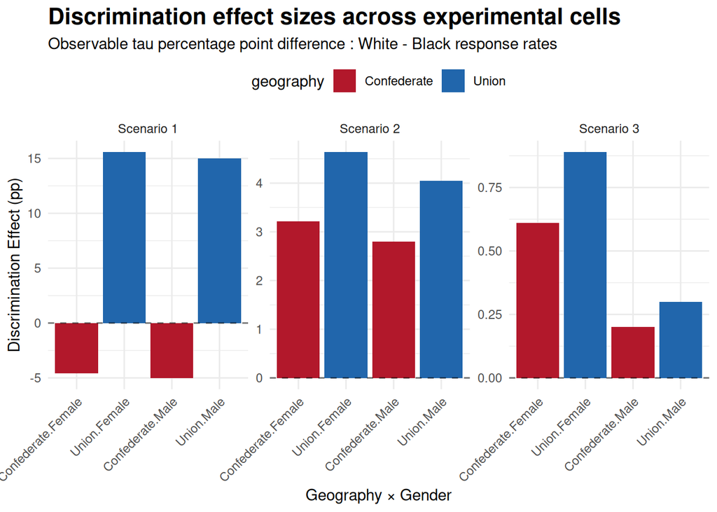

```r
create_discrimination_plot()
```

```r
generate_summary_report(power_results)
```

```
## Scenario 1: Jose/Colin (29-58%):
##   - Sample size for 80% power: n = 800
##   - Power at n=400: 57.8%
##   - Power at n=1000: 92.2%
##
## Scenario 2: Bertrand (6-13%):
##   - Sample size for 80% power: n = >2000
##   - Power at n=400: 6.2%
##   - Power at n=1000: 6.3%
##
## Scenario 3: Block (1-5%):
##   - Sample size for 80% power: n = >2000
##   - Power at n=400: 3.8%
##   - Power at n=1000: 4.6%
```

```r
experiment_data %>%
  group_by(geography, race, gender) %>%
  summarise(
    BudgetAccepted_S1 = mean(budget_accepted1, na.rm = TRUE),
    BudgetAccepted_S2 = mean(budget_accepted2, na.rm = TRUE),
    BudgetAccepted_S3 = mean(budget_accepted3, na.rm = TRUE),
    n_S1 = sum(!is.na(budget_accepted1)),
    n_S2 = sum(!is.na(budget_accepted2)),
    n_S3 = sum(!is.na(budget_accepted3)),
    .groups = "drop"
  ) %>%
  print(row.names = FALSE)
```

```
## # A tibble: 8 × 9
##   geography   race  gender BudgetAccepted_S1 BudgetAccepted_S2 BudgetAccepted_S3
##   <fct>       <fct> <fct>              <dbl>             <dbl>             <dbl>
## 1 Union       White Male               0.72              0.75              0.5
## 2 Union       White Female             0.733             1                 0.5
## 3 Union       Black Male               0.65              0.667             0.667
## 4 Union       Black Female             0.625             0.857             0
## 5 Confederate White Male               0.789             0.833             1
## 6 Confederate White Female             0.75              0.5               1
## 7 Confederate Black Male               0.368             0.667             1
## 8 Confederate Black Female             0.632             0.4               1
## # ℹ 3 more variables: n_S1 <int>, n_S2 <int>, n_S3 <int>
```

# Final Notes

- Race and geography are measurably able to affect reply probability, and the magnitude varies by the scenario
- Gender effects are present but secondary to race
- We were able to balance region throughout our designs and blocks
- Budget was modeled at 70% for white and 55% for black names, an arbitrary baseline
- Power analysis shows ample statistical power to detect discrimination in high-rate scenarios, but it’s marginal when the mean differences are subtle and reply rates are low.